## Community transport patterns across different time periods

This dynamic report explores transport patterns in my community using observational data collected at different times of the day. The data were collected in four time periods: morning, midday, afternoon, and evening.

[figure not shown]

There are currently 42 observations in the dataset.

The busiest time period is Morning, with 13 observations.

The most common transport mode is Walking.

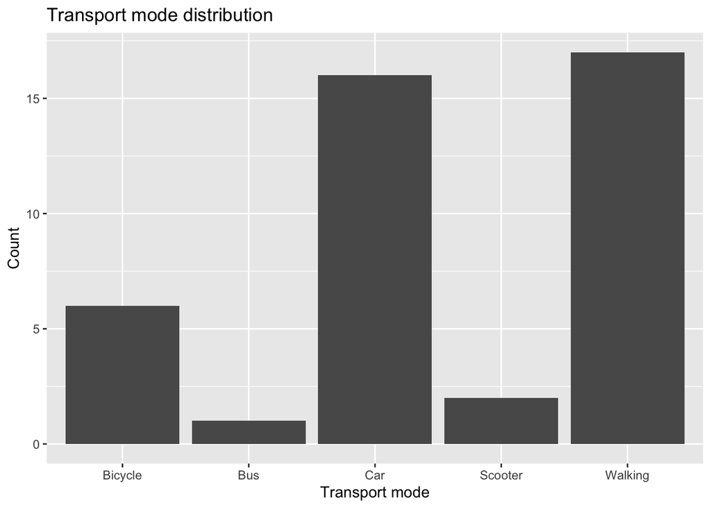

This bar chart shows the overall distribution of transport modes in the sample. The most common transport mode is Walking, with 17 observations. 🚶🚶🚶🚶🚶🚶🚶🚶🚶🚶🚶🚶🚶🚶🚶🚶🚶

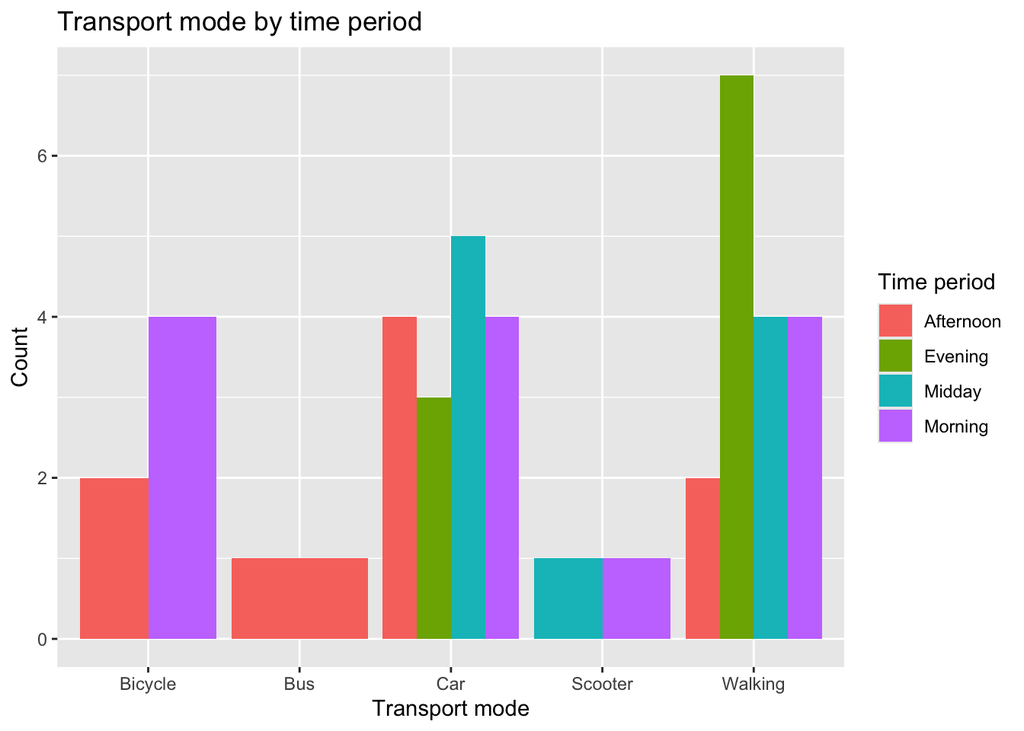

This chart compares transport modes across different time periods and shows that transport behaviour changes throughout the day. The busiest time period is Morning, with 13 observations.

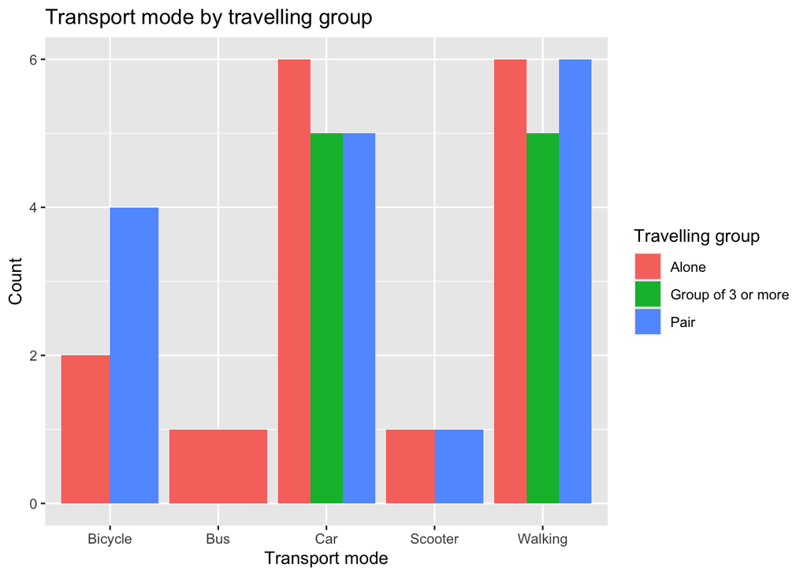

## Summary

Overall, there are 42 observations in this dataset.

The most common transport mode is Walking, while the busiest time period is Morning.

These patterns indicate that transport behaviour varies across the day and is influenced by convenience and daily routines.

[figure not shown]